# Análisis de datos ómicos - PEC1

Malena Díaz

2024-11-03

# Lectura de datos

```r
#Añadimos datos "ficticios" sobre las variables recogidas para crear un experiment set más completo.

categorias <- c("Carbohidrato", "Otro", "Aminoácido", "Otro", "Metabolito", "Aminoácido", "Lípido", "Lípido", "Otro", "Otro", "Carbohidrato", "Carbohidrato", "Lípido", "Aminoácido", "Aminoácido", "Otro", "Otro", "Metabolito", "Otro", "Otro", "Otro", "Otro", "Otro", "Carbohidrato", "Metabolito", "Carbohidrato", "Aminoácido", "Aminoácido", "Otro", "Otro", "Otro", "Aminoácido", "Otro", "Aminoácido", "Otro", "Aminoácido", "Aminoácido", "Otro", "Otro", "Otro", "Otro", "Otro", "Otro", "Metabolito", "Otro", "Aminoácido", "Metabolito", "Carbohidrato", "Otro", "Otro", "Aminoácido", "Otro", "Otro", "Aminoácido", "Aminoácido", "Otro", "Aminoácido", "Carbohidrato", "Otro", "Metabolito", "Otro", "Aminoácido", "Aminoácido")

unidad_medida <- rep("mmol/L", length(categorias))
```

```r
#Preparamos los datos
rownames(data) <- data[, "Patient ID"]
counts <- t(data[, 3:ncol(data)])
counts <- apply(counts, 2, as.numeric)
rownames(counts) <- colnames(data[, 3:ncol(data)])

#Prepara los datos de columnas
labels <- as.factor(data[,2])
colData <- DataFrame(group=labels, row.names=colnames(counts))

# Crear el dataframe
rowData <- data.frame( UnidadMedida = unidad_medida, Categoria = categorias,
                       row.names = rownames(counts))

myDesc <- list(name="Malena Díaz Río", lab="UOC - Análisis de datos ómicos", contact="mdiazrio@uoc.edu", url="https://rest.xialab.ca/api/download/metaboanalyst/human_cachexia.csv", title="Human cachexia")

se <- SummarizedExperiment(assays=list(counts=counts), rowData=rowData,
                           colData=colData, metadata = myDesc)

metadata(se)
```

```
## $name
## [1] "Malena Díaz Río"
##
## $lab
## [1] "UOC - Análisis de datos ómicos"
##
## $contact
## [1] "mdiazrio@uoc.edu"
##
## $url
## [1] "https://rest.xialab.ca/api/download/metaboanalyst/human_cachexia.csv"
##
## $title
## [1] "Human cachexia"
```

```r
#exportamos el objeto
save(se, file='data/human_cachexia_summarized_exp.rda')
```

# Preprocesado, control de calidad y normalización

```r
#cargar los datos
load('data/human_cachexia_summarized_exp.rda')
se
```

```
## class: SummarizedExperiment
## dim: 63 77
## metadata(5): name lab contact url title
## assays(1): counts
## rownames(63): 1,6-Anhydro-beta-D-glucose 1-Methylnicotinamide ...
##   pi-Methylhistidine tau-Methylhistidine
## rowData names(2): UnidadMedida Categoria
## colnames(77): PIF_178 PIF_087 ... NETL_003_V1 NETL_003_V2
## colData names(1): group
```

## Análisis de valores faltantes

```r
#Obtener el conteo de nulos por variable
n_nulos_por_fila <- apply(assays(se)$counts, 1, function(x) sum(is.na(x)))
sum(n_nulos_por_fila)
```

```
## [1] 0
```

## Normalización de datos

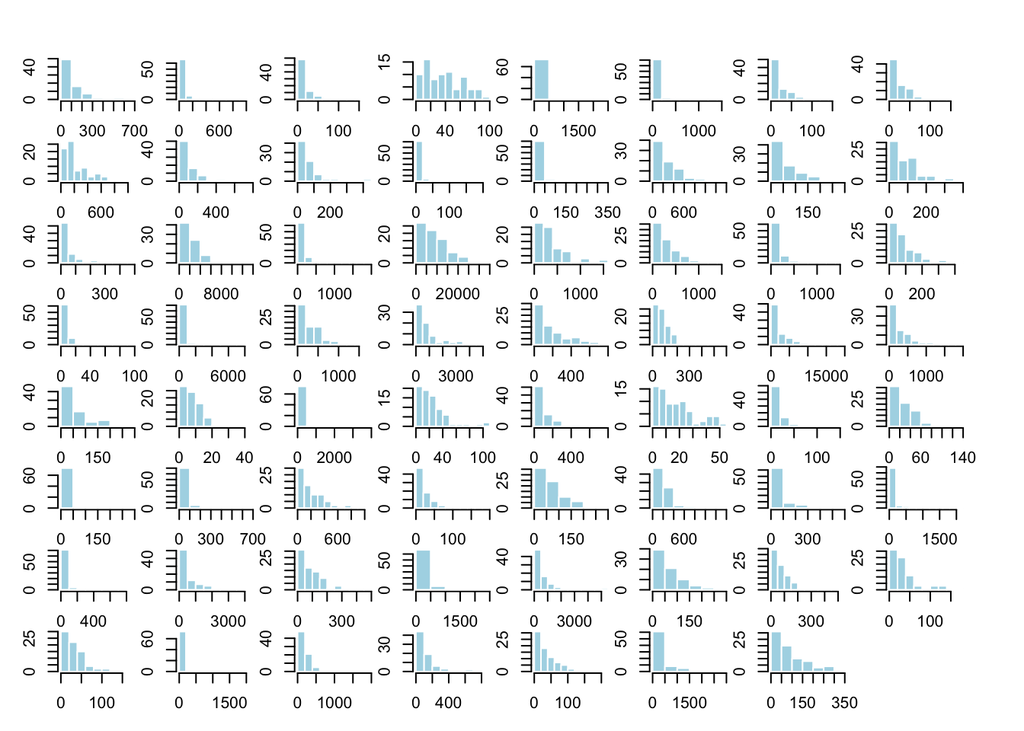

```r
# Tenemos 63 variables, lo pintaremos en una matriz 8x8
par(mfrow = c(8, 8), mar = c(1, 1, 1, 1), oma = c(2, 2, 2, 2))

# Crear un histograma por variable.
for (i in 1:63) {
  hist(assays(se)$counts[i, ], main = "", xlab = "", ylab = "", col = "lightblue", border = "white")
}
```

A simple vista, observamos que las variables no presentan una distribución normal por lo que aplicar el método IQR para la detección de valores anómalos resultará en la eliminación de valores válidos. Para crear una distribución normal, procederemos a normalizarla primero.

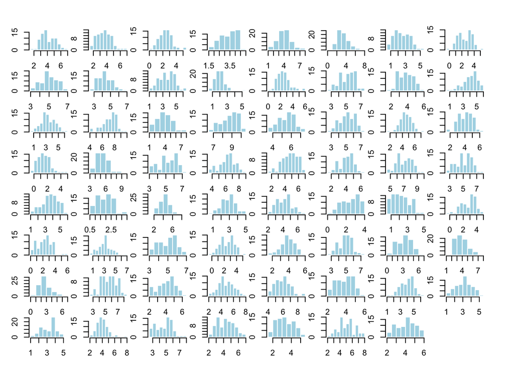

```r
par(mfrow = c(8, 8), mar = c(1, 1, 1, 1), oma = c(2, 2, 2, 2))
for (i in 1:63) {
  hist(log(assays(se)$counts[i, ]), main = "", xlab = "", ylab = "", col = "lightblue", border = "white")
}
```

Al aplicar el logaritmo podemos observar una distribución normal. Nos quedaremos con estás variables. Por ello, guardaremos los datos del logaritmo en el experimento.

```r
#Añadiremos estos datos al experimento para poder acceder a ellos fácilmente
assays(se)$log_counts <- log(assays(se)$counts)
```

## Análisis de valores anómalos

Ahora aplicamos el método IQR sobre las variables en forma logarítmica.

```r
# Calcular los cuartiles y el IQR
Q1Q3 <- apply(assays(se)$log_counts, 1, function(x) quantile(x, probs = c(0.25, 0.75)))
IQR <- Q1Q3[2,] - Q1Q3[1,]

# Definir límites para detectar outliers
limite_inferior <- Q1Q3[1,] - 1.5 * IQR
limite_superior <- Q1Q3[2,] + 1.5 * IQR

# Asignar un valor nulo a los valores anómalos
tmp_data <- assays(se)$log_counts
for (i in 1:nrow(tmp_data)) {
  tmp_data[i, tmp_data[i, ] < limite_inferior[i]] <- NaN
  tmp_data[i, tmp_data[i, ] > limite_superior[i]] <- NaN
}
n_nulos_por_fila <- apply(tmp_data, 1, function(x) sum(is.na(x)))
paste("Se han detectado", sum(n_nulos_por_fila), "valores anómalos")
```

```
## [1] "Se han detectado 32 valores anómalos"
```

```r
names(n_nulos_por_fila[n_nulos_por_fila>0])
```

```
##  [1] "1-Methylnicotinamide" "2-Aminobutyrate"      "2-Oxoglutarate"
##  [4] "3-Aminoisobutyrate"   "Acetone"              "Adipate"
##  [7] "Betaine"              "Citrate"              "Formate"
## [10] "Fumarate"             "Glucose"              "Lactate"
## [13] "Pantothenate"         "Sucrose"              "Tartrate"
## [16] "Xylose"
```

Para controlar que el proceso de supresión de valores anómalos a través del rango IQR se ha ejecutado correctamente, representaremos aquellas variables en las cuales se ha detectado un valor anómalo junto con los rangos definidos.

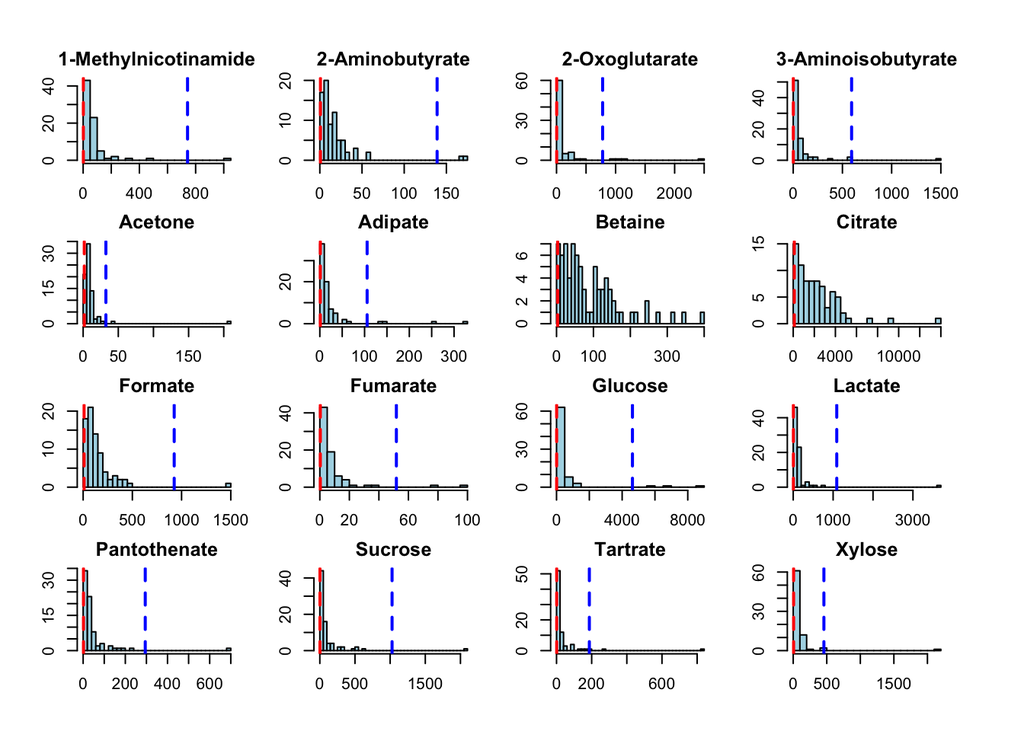

```r
par(mfrow = c(4,4), mar = c(2, 2, 2, 2), oma = c(2, 2, 2, 2))

#crearemos un histograma con dos barras verticales que indiquen los rangos
for (i in names(n_nulos_por_fila[n_nulos_por_fila>0])) {
  hist(assays(se)$counts[i, ], main = paste(i), xlab = "", col = "lightblue", border = "black", breaks = 30)

  # Añadir límite inferior y superior
  abline(v = exp(limite_inferior[i]), col = "red", lty = 2, lwd = 2)
  abline(v = exp(limite_superior[i]), col = "blue", lty = 2, lwd = 2)
}
```

```r
tmp_data <- assays(se)$log_counts
for (i in 1:nrow(tmp_data)) {
  assays(se)$log_counts[i, tmp_data[i, ] < limite_inferior[i]] <- limite_inferior[i]
  assays(se)$log_counts[i, tmp_data[i, ] > limite_superior[i]] <- limite_superior[i]
  assays(se)$counts[i, tmp_data[i, ] < limite_inferior[i]] <- exp(limite_superior[i])
  assays(se)$counts[i, tmp_data[i, ] > limite_superior[i]] <- exp(limite_superior[i])
}
```

# Exploración de los datos

### Análisis de distribuciones

Creamos una tabla resumen con las diferencias en la media y desviación estándar para cada grupo y para cada variable. Además para cada variable realizamos una prueba t-test frente a los datos normalizadas que nos permita cuantificar en que medida se diferencian ambas poblaciones.

```r
resultados <- list() #Crear lista vacía

for (var in rownames(rowData(se))) {
  # Calcular la media y desviación estándar por grupo
  stats <- aggregate(assays(se)$counts[var,], by = list(colData(se)$group), FUN = function(x) c(media = mean(x), sd = sd(x)))

  # Realizar la prueba t
  t_test <- t.test(assays(se)$log_counts[var,] ~ colData(se)$group)

  # Almacenar resultados
  resultados[[var]] <- data.frame(
    "Grupo 1 media ± sd" = paste(round(stats[1, 2][[1]][1], 2), " ± ", round(stats[1, 2][[2]][1], 2)),
    "Grupo 2 media ± sd" = paste(round(stats[2, 2][[1]][1], 2), " ± ", round(stats[2, 2][[2]][1], 2)),
    p_value = round(t_test$p.value,5)
  )
}

resultados_df <- do.call(rbind, resultados)

# FDR
resultados_df$fdr <- round(p.adjust(resultados_df$p_value, method = "fdr"), 5)

print(resultados_df[order(resultados_df$p_value), ])
```

```
##                              Grupo.1.media...sd  Grupo.2.media...sd p_value
## Glucose                      665.84  ±  1096.38     140.96  ±  99.2 0.00000
## Adipate                          25.46  ±  28.2      8.99  ±  10.43 0.00001
## Quinolinate                     83.75  ±  53.41     39.32  ±  33.76 0.00001
## Leucine                         31.26  ±  24.23      13.56  ±  9.16 0.00002
## Valine                          45.58  ±  32.49      20.13  ±  15.1 0.00003
## myo-Inositol                  181.84  ±  197.77     62.64  ±  70.45 0.00003
## 3-Hydroxyisovalerate            27.61  ±  27.44        12.31  ±  17 0.00004
## N,N-Dimethylglycine             34.49  ±  26.59      13.6  ±  13.44 0.00004
## 3-Hydroxybutyrate               29.26  ±  30.73        9.9  ±  7.99 0.00006
## Succinate                       79.63  ±  98.58     29.84  ±  44.99 0.00007
## Creatine                      174.91  ±  335.36      51.5  ±  87.24 0.00009
## Glutamine                     391.41  ±  311.57   174.43  ±  195.36 0.00011
## Acetate                          85.63  ±  90.6      35.6  ±  42.93 0.00012
## cis-Aconitate                 276.03  ±  331.29      91.72  ±  84.9 0.00012
## Pyroglutamate                 270.29  ±  212.19    119.26  ±  98.63 0.00014
## Alanine                       347.59  ±  281.73   157.58  ±  156.14 0.00017
## Dimethylamine                 453.58  ±  347.08   208.68  ±  139.19 0.00021
## Tryptophan                      81.82  ±  59.08     41.83  ±  42.08 0.00021
## Methylamine                     21.22  ±  13.78     11.36  ±  12.03 0.00022
## Betaine                         112.25  ±  83.2    95.69  ±  218.79 0.00025
## Formate                       175.75  ±  160.49   115.11  ±  168.39 0.00027
## Creatinine                 10722.14  ±  6905.41 5619.17  ±  4228.76 0.00043
## Sucrose                       127.63  ±  185.78    55.58  ±  113.29 0.00049
## Lactate                       163.38  ±  199.16     65.75  ±  55.81 0.00068
## Tyrosine                       100.74  ±  94.08     52.01  ±  51.22 0.00095
## 3-Indoxylsulfate              265.16  ±  211.66   146.38  ±  146.98 0.00117
## Threonine                       118.23  ±  95.3     59.52  ±  57.43 0.00117
## Serine                         245.83  ±  214.4    122.26  ±  88.89 0.00123
## Asparagine                      75.39  ±  57.79      41.75  ±  40.2 0.00132
## Xylose                          92.96  ±  90.58     56.51  ±  80.25 0.00136
## trans-Aconitate                 48.81  ±  39.95     27.81  ±  35.95 0.00140
## Fumarate                          9.46  ±  11.1       4.55  ±  6.39 0.00153
## Pyruvate                        26.87  ±  29.62     12.57  ±  15.71 0.00159
## Histidine                        364.23  ±  351   180.47  ±  199.01 0.00161
## 2-Aminobutyrate                 22.36  ±  28.17       9.53  ±  7.31 0.00181
## 2-Hydroxyisobutyrate            43.24  ±  23.44     27.87  ±  21.99 0.00320
## Lysine                         121.28  ±  97.52     89.23  ±  162.2 0.00327
## Fucose                          108.6  ±  91.13     57.44  ±  47.17 0.00357
## Trigonelline                  359.64  ±  476.94   130.69  ±  146.23 0.00411
```

[output cut: 73 more lines]

```
## pi-Methylhistidine         0.03815
## Carnitine                  0.03833
## Glycolate                  0.03841
## Guanidoacetate             0.04325
## 4-Hydroxyphenylacetate     0.04601
## 2-Oxoglutarate             0.05278
## Isoleucine                 0.06404
## 1-Methylnicotinamide       0.07222
## Hypoxanthine               0.11720
## 3-Aminoisobutyrate         0.18091
## Pantothenate               0.19624
## Tartrate                   0.19923
## Methylguanidine            0.24534
## Uracil                     0.31285
## Acetone                    0.54268
```

Representaremos las distribuciones, diferenciadas por grupo, de aquellas variables que han presentado una mayor diferencia estadística.

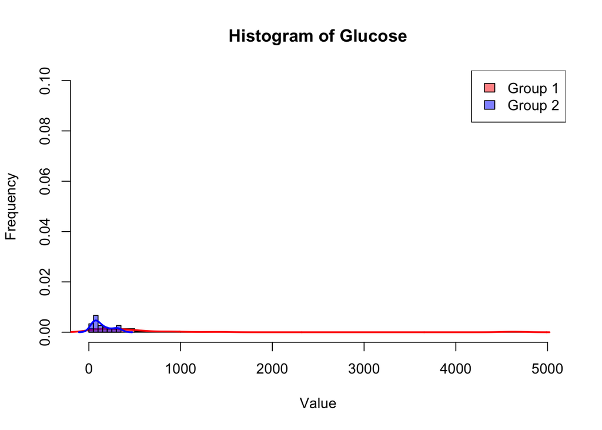

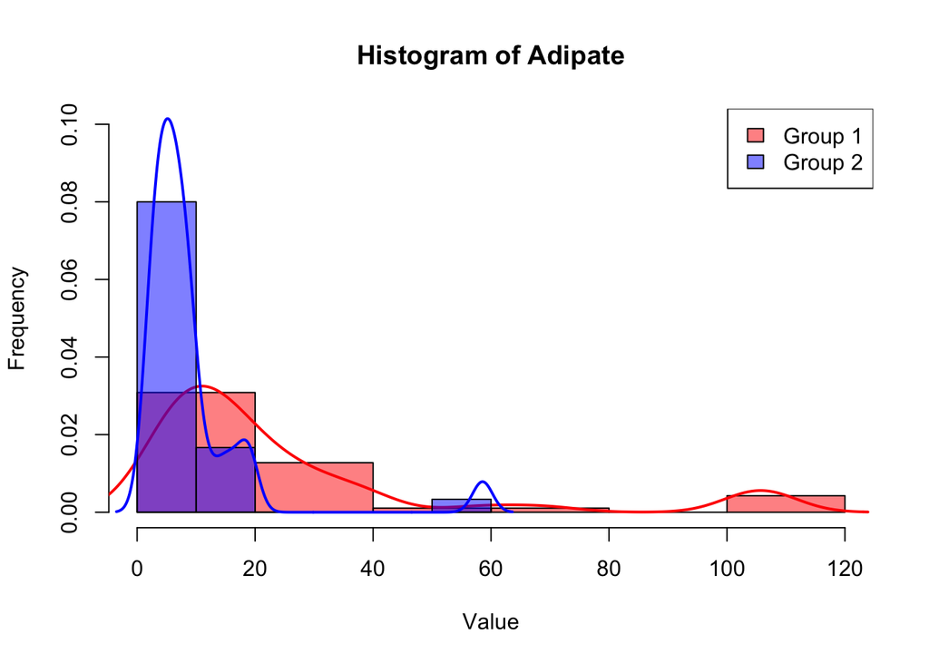

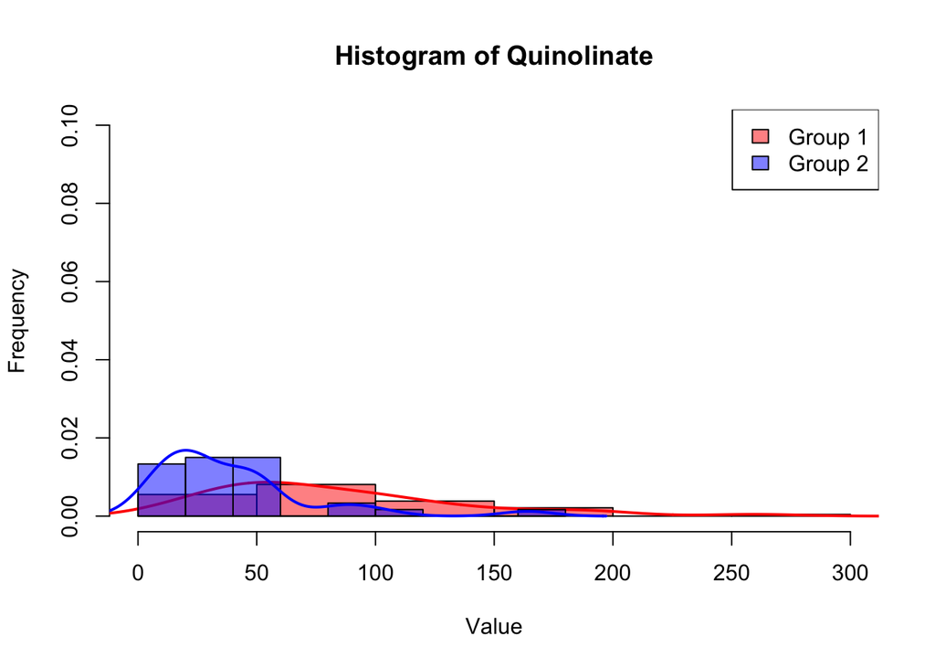

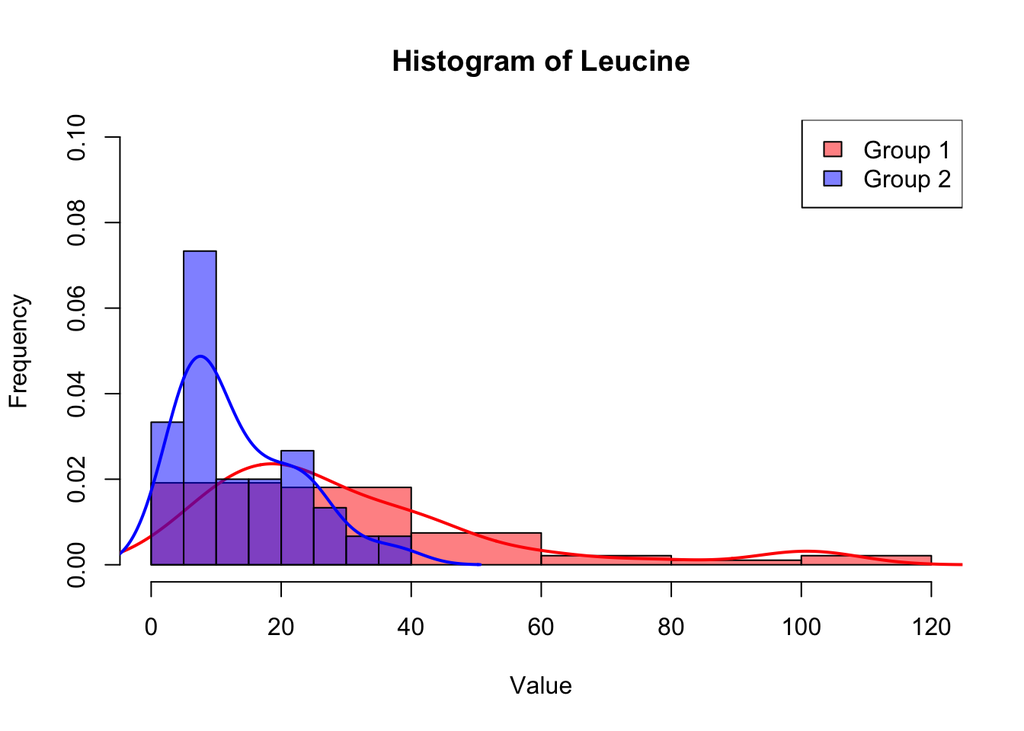

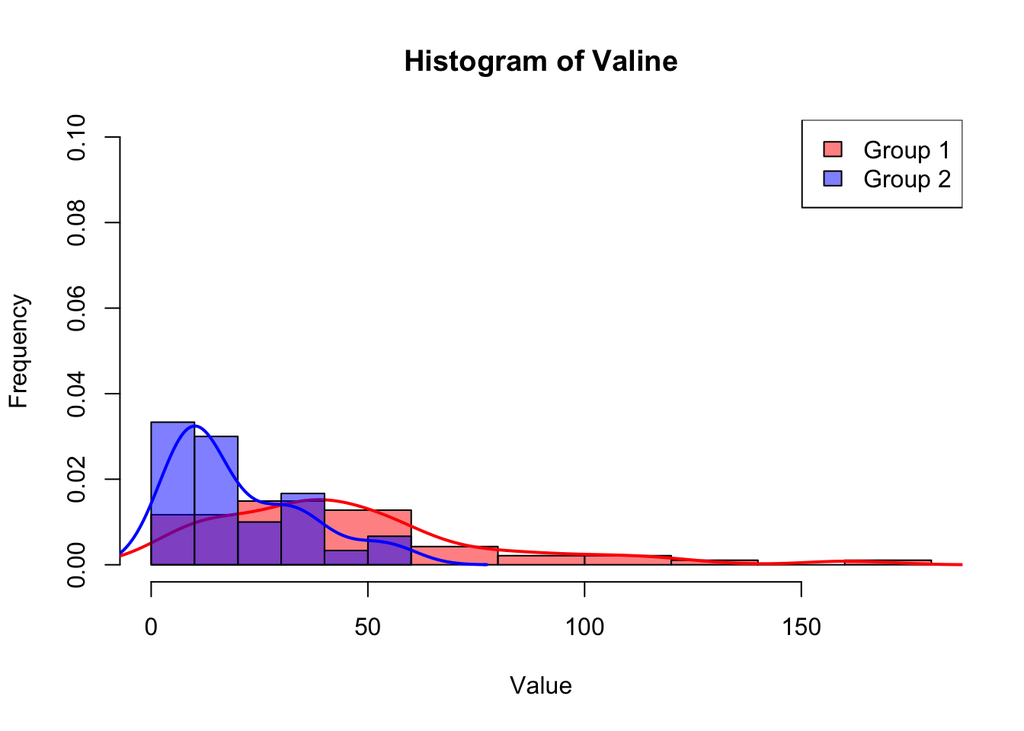

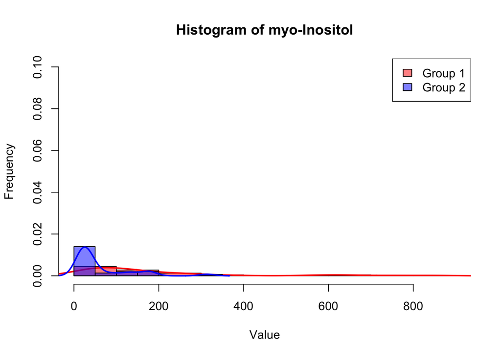

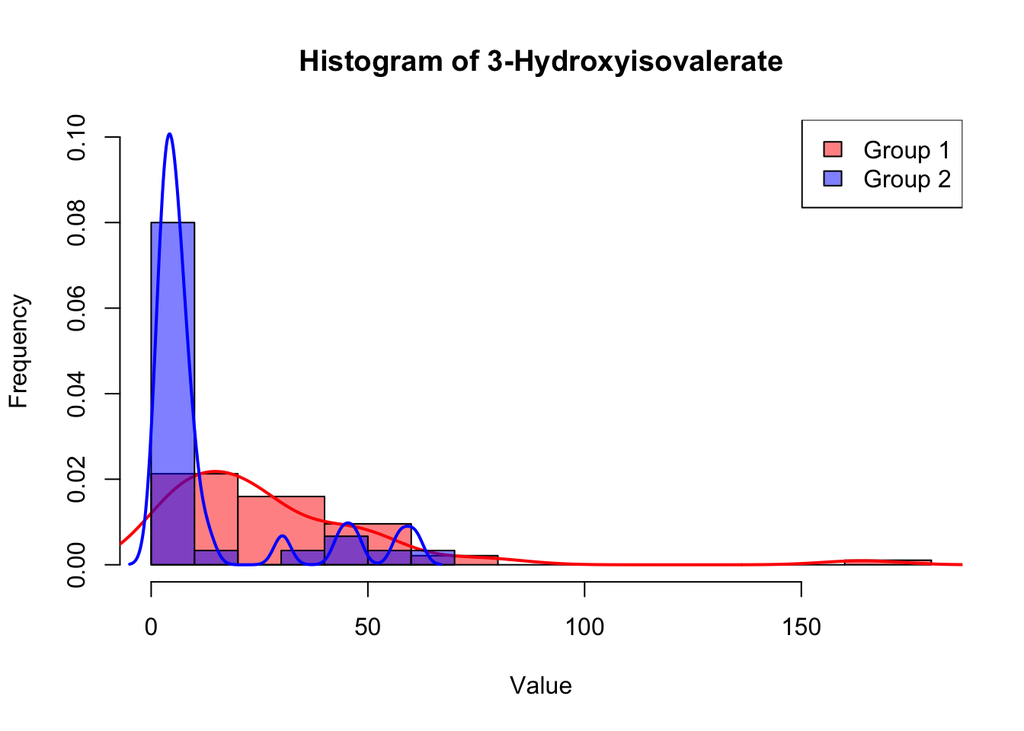

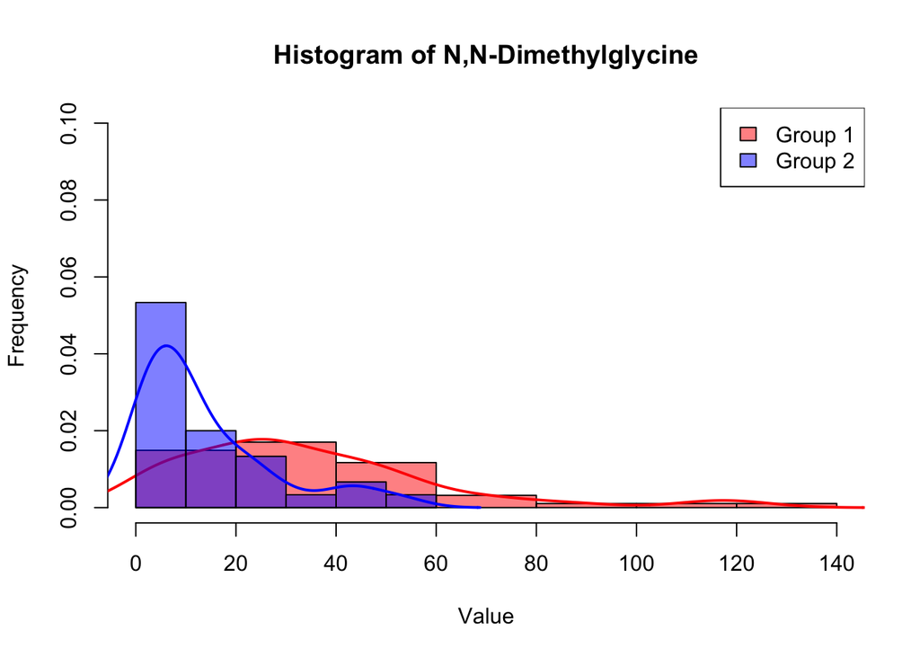

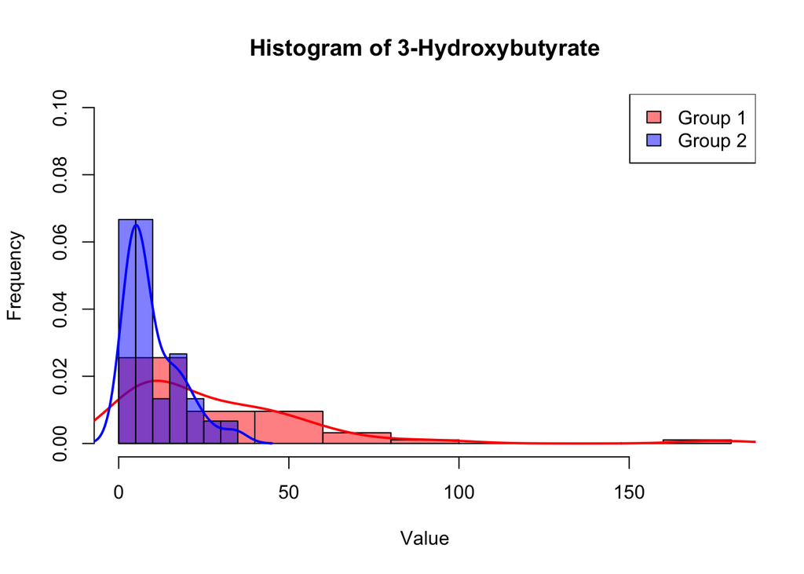

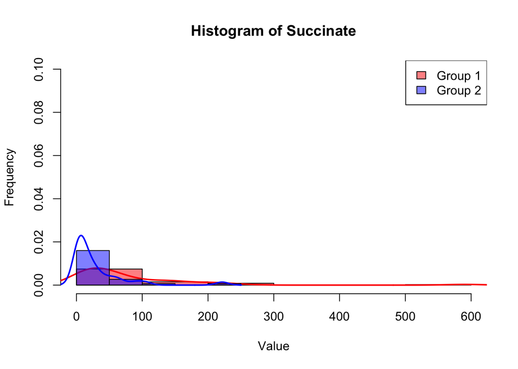

```r
for (var in rownames(resultados_df[order(resultados_df$p_value), ])[0:10]){
  # Set up the plotting area
  hist(assays(se[, se$group == "cachexic"])$counts[var,],
       col = rgb(1, 0, 0, 0.5),
       xlab = "Value",
       ylab = "Frequency",
       ylim=c(0,0.1),
       main = paste("Histogram of", var),
       freq = FALSE)
  lines(density(assays(se[, se$group == "cachexic"])$counts[var,]), col = "red", lwd = 2)

  # Overlay the histogram for Group 2
  hist(assays(se[, se$group == "control"])$counts[var,],
       col = rgb(0, 0, 1, 0.5),
       add = TRUE,
       freq = FALSE)
  lines(density(assays(se[, se$group == "control"])$counts[var,]), col = "blue", lwd = 2)

  # Add a legend
  legend("topright",
         legend = c("Group 1", "Group 2"),
         fill = c(rgb(1, 0, 0, 0.5), rgb(0, 0, 1, 0.5)))
}
```

### Análisis de correlaciones

Calculamos la correlación de cada variable frente a la variable objetivo y representamos aquellas con una correlación más alta en un diagrama de barras.

```r
correlations <- cor(t(assays(se)$counts), as.numeric(se$group))
paste("Máxima correlación:", max(correlations))
```

```
## [1] "Máxima correlación: -0.00538438442214171"
```

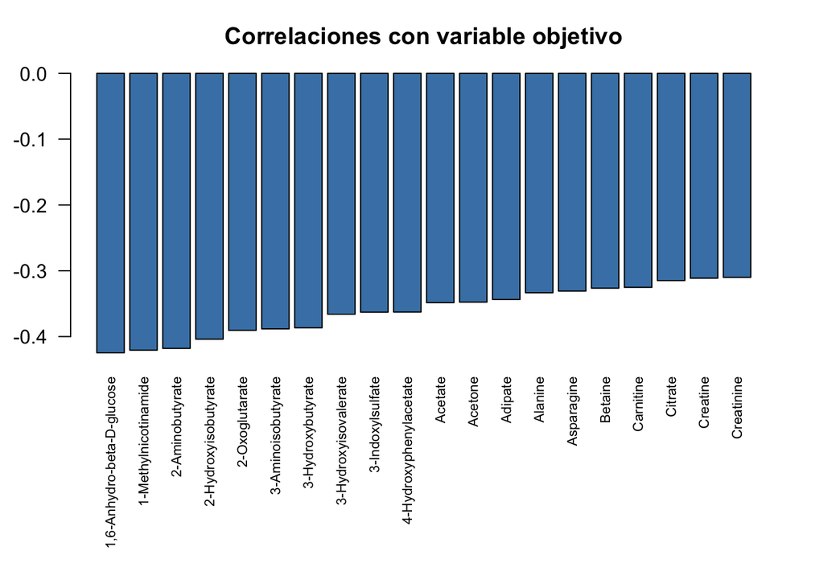

```r
correlations[,1] <- sort(correlations)

# Diagrama de barras
par(mar = c(10, 3, 3, 2))
barplot(correlations[0:20,1],
        names.arg = rownames(correlations[0:20]),
        col = "steelblue",
        main = "Correlaciones con variable objetivo",
        ylab = "Counts",
        border = "black",
        las = 2, cex.names=0.7)
```

También es importante estudiar las correlaciones entre variables. Para ello calculamos el coeficiente de Pearson.

```r
cor_matrix <- cor(t(assays(se)$counts))

library(reshape2)

#Dar formato al dataframe para no ver cada par de variables repetidas ni la correlación entre la propia variable.

cor_long <- melt(cor_matrix)

colnames(cor_long) <- c("Variable1", "Variable2", "Correlation")
cor_long <- cor_long[cor_long$Variable1 != cor_long$Variable2, ]
cor_long <- cor_long[order(-abs(cor_long$Correlation)), ]
cor_long <- cor_long[!duplicated(t(apply(cor_long[, 1:2], 1, sort))), ]

print(cor_long)
```

```
##                   Variable1                  Variable2  Correlation
## 2262                 Valine                    Leucine  0.880414845
## 1684                 Serine                  Glutamine  0.867440329
## 1218          Dimethylamine                 Creatinine  0.862347096
## 277                Fumarate             2-Oxoglutarate  0.860289226
## 2008               Tyrosine                  Histidine  0.857268571
## 909               Glutamine                 Asparagine  0.855696397
## 1689              Threonine                  Glutamine  0.847766900
## 1240          Pyroglutamate                 Creatinine  0.844379874
## 876                  Valine                    Alanine  0.836696743
## 1752              Threonine                    Glycine  0.835274349
## 933               Threonine                 Asparagine  0.831586790
## 1219           Ethanolamine                 Creatinine  0.819000424
## 1303          Pyroglutamate              Dimethylamine  0.816728945
## 1356           Hypoxanthine               Ethanolamine  0.808895514
```

[output cut: 1939 more lines]

Podemos observar estas correlaciones en un diagrama scatter:

[figure not shown]

```r
data <- t(assays(se)$counts)

#Seleccionamos las primeras 8 filas de esta tabla
top_correlations <- cor_long[order(abs(cor_long$Correlation), decreasing = TRUE), ][1:9, ]

par(mfrow = c(3, 3), mar = c(2, 2, 1, 1))

for (i in 1:nrow(top_correlations)) {

  var1 <- top_correlations$Variable1[i]  # Primera variable
  var2 <- top_correlations$Variable2[i]  # Segunda variable
  corr_value <- round(top_correlations$Correlation[i], 2)  # Correlación

  plot(assays(se)$counts[, var1 ], assays(se)$counts[, var2],
       main = paste(var1, "vs", var2, "- Corr:", corr_value),
       xlab = var1,
       ylab = var2,
       pch = 19,
       col = "blue")
}
```

Para cada par variables con una correlación mayor a 0.8 escogeremos aquella que tenga un menor p-valor.

```r
columnas_borrar <- list()

# Para cada par de variables con correlación > 0.8
for (i in rownames(cor_long[cor_long$Correlation > 0.8, ])) {

  var1 <- cor_long[i, "Variable1"] #nombre de las variables
  var2 <- cor_long[i, "Variable2"]

  p_val1 <- resultados_df[var1, "p_value"] #p-valor
  p_val2 <- resultados_df[var2, "p_value"]

  if (p_val1 < p_val2) { #columna a borrar
    columnas_borrar[[i]] <- var2
  } else {
    columnas_borrar[[i]] <- var1
  }
}

se <- se[!rownames(se) %in% unlist(columnas_borrar), ]
```

# Análisis estadístico

Creamos una regresión logística con aquellas variables disponibles que hanmostrado presentar más diferencias entre ambos grupos en el apartado exploración de datos.

```r
resultados_df <- resultados_df[!rownames(resultados_df) %in% unlist(columnas_borrar), ]

top_20_rows <- rownames(resultados_df[order(resultados_df$p_value), ])[1:20]

top_20_pvalue <- t(assays(se)$counts[top_20_rows, ])

linear_model <- glm(as.numeric(se$group) - 1 ~ top_20_pvalue, family=binomial)
summary(linear_model)
```

```
##
## Call:
## glm(formula = as.numeric(se$group) - 1 ~ top_20_pvalue, family = binomial)
##
## Coefficients:
##                                    Estimate Std. Error z value Pr(>|z|)
## (Intercept)                        3.277067   1.066774   3.072  0.00213 **
## top_20_pvalueGlucose              -0.019432   0.009323  -2.084  0.03713 *
## top_20_pvalueAdipate               0.009123   0.057112   0.160  0.87309
## top_20_pvalueQuinolinate          -0.013501   0.017422  -0.775  0.43838
## top_20_pvalueLeucine              -0.073837   0.076723  -0.962  0.33586
## top_20_pvaluemyo-Inositol         -0.005248   0.004076  -1.288  0.19785
## top_20_pvalue3-Hydroxyisovalerate -0.011047   0.045536  -0.243  0.80832
## top_20_pvalueN,N-Dimethylglycine  -0.120911   0.053328  -2.267  0.02337 *
## top_20_pvalue3-Hydroxybutyrate    -0.163760   0.079959  -2.048  0.04056 *
## top_20_pvalueSuccinate             0.061447   0.021771   2.822  0.00477 **
## top_20_pvalueCreatine             -0.006741   0.003086  -2.184  0.02894 *
## top_20_pvalueGlutamine             0.012290   0.006897   1.782  0.07475 .
## top_20_pvalueAcetate              -0.033844   0.017658  -1.917  0.05529 .
## top_20_pvaluecis-Aconitate         0.002121   0.005981   0.355  0.72289
## top_20_pvaluePyroglutamate         0.014229   0.007589   1.875  0.06079 .
## top_20_pvalueTryptophan           -0.039738   0.025632  -1.550  0.12107
## top_20_pvalueMethylamine           0.133378   0.080968   1.647  0.09950 .
## top_20_pvalueBetaine               0.023410   0.012720   1.840  0.06572 .
## top_20_pvalueFormate              -0.008537   0.008780  -0.972  0.33091
## top_20_pvalueSucrose               0.006523   0.006701   0.973  0.33033
## top_20_pvalueLactate               0.012723   0.010794   1.179  0.23854
## ---
## Signif. codes:  0 '***' 0.001 '**' 0.01 '*' 0.05 '.' 0.1 ' ' 1
##
## (Dispersion parameter for binomial family taken to be 1)
##
##     Null deviance: 102.960  on 76  degrees of freedom
## Residual deviance:  50.282  on 56  degrees of freedom
## AIC: 92.282
##
## Number of Fisher Scoring iterations: 10
```

También crearemos una serie de regresiones logísticas con diferentes subconjuntos de variables para determinar que combinación de estas podría obtener un mejor rendimiento en el diagnóstico de pacientes con caquexia.

```r
group_data <- as.numeric(se$group) - 1

# Modelo vacío
modelo_vacio <- glm(group_data ~ 1, family = binomial, data=as.data.frame(top_20_pvalue))

# Modelo completo (con todas las variables independientes)
modelo_completo <- glm(group_data ~ . , family = binomial, data=as.data.frame(top_20_pvalue))
step.model <- stepAIC(modelo_vacio, direction = "both",
                      scope = modelo_completo, trace = FALSE)

# Aplicar selección hacia adelante
modelo_seleccionado <- step(modelo_vacio,
                             direction = "forward",
                             scope = formula(modelo_completo), trace=0)
# Resumen del modelo seleccionado
summary(step.model)
```

```
##
## Call:
## glm(formula = group_data ~ 1, family = binomial, data = as.data.frame(top_20_pvalue))
##
## Coefficients:
##             Estimate Std. Error z value Pr(>|z|)
## (Intercept)  -0.4490     0.2337  -1.921   0.0547 .
## ---
## Signif. codes:  0 '***' 0.001 '**' 0.01 '*' 0.05 '.' 0.1 ' ' 1
##
## (Dispersion parameter for binomial family taken to be 1)
##
##     Null deviance: 102.96  on 76  degrees of freedom
## Residual deviance: 102.96  on 76  degrees of freedom
## AIC: 104.96
##
## Number of Fisher Scoring iterations: 4
```